# TP n°6 : Arbres binaires de recherche

## Arbres binaires de recherche

Un *arbre binaire de recherche* est un arbre binaire dont les étiquettes appartiennent à un ensemble $X$ ordonné et tel que pour tout nœud $N$, l'étiquette de $N$ est supérieure ou égale à toutes les étiquettes présentes dans le fils gauche de $N$ et inférieure ou égale à toutes les étiquettes présentes dans le fils droit de $N$.

Dans la suite, on utilisera des arbres binaires de recherche ne contenant que des étiquettes distinctes.

#### Question 1

Parmi les trois arbres suivants, lesquels sur des arbres binaires de recherche ?

Arbre n°1

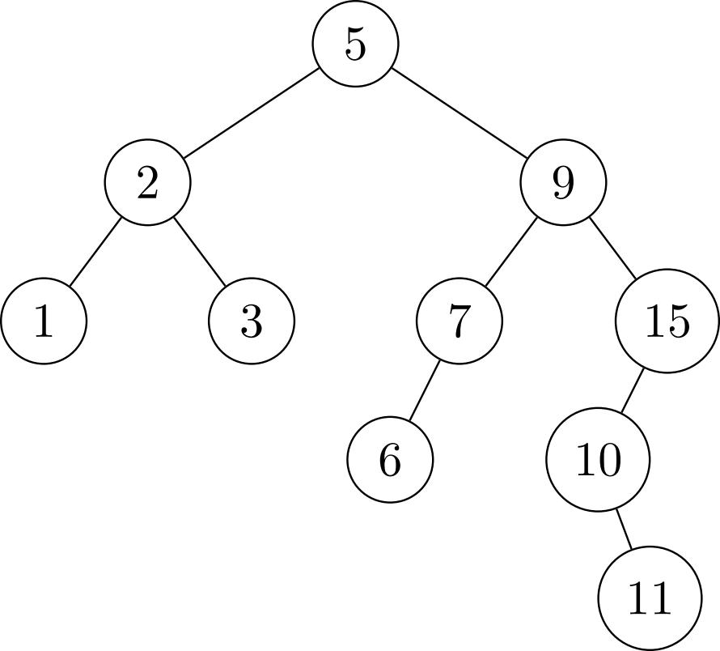

Arbre n°2

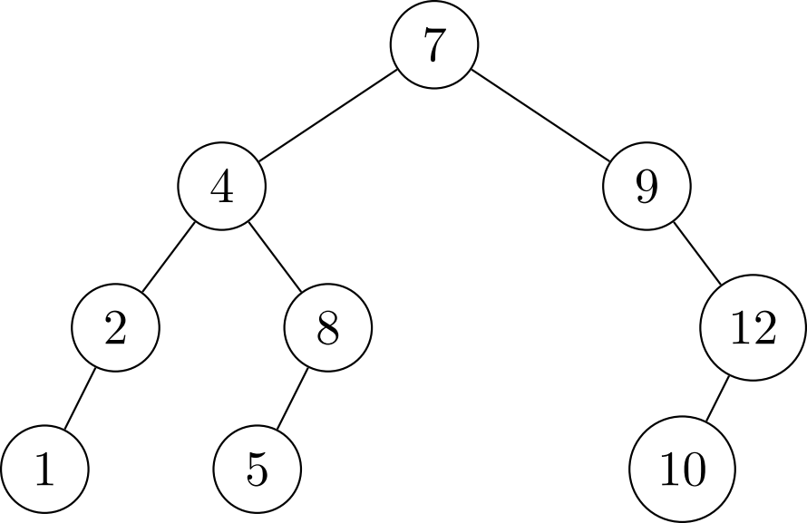

Arbre n°3

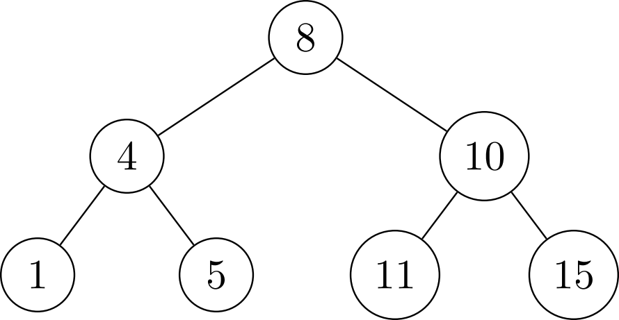

> Seul l'arbre 1 est un arbre binaire de recherche.

> Dans l'arbre 2, le sous-arbre gauche de 7 contient 8.

> Dans l'arbre 3, le sous-arbre gauche de 10 contient 11.

#### Question 2

Définir un type `'a arbre` pour représenter un arbre binaire avec des étiquettes de type `'a`. Définir ensuite trois variables `arbre1`, `arbre2` et `arbre3` correspondant aux trois arbres précédents.

```python
type 'a arbre =
  | Vide
  | Noeud of 'a * 'a arbre * 'a arbre
;;


let arbre1 = Noeud (5,
                    Noeud (2, Noeud (1, Vide, Vide), Noeud (3, Vide, Vide) ),
                    Noeud (9,
                           Noeud (7, Noeud(6, Vide, Vide), Vide),
                           Noeud(15, Noeud(10, Vide, Noeud(11, Vide, Vide)), Vide)
                           )

                    );;

let arbre2 = Noeud (7,
                    Noeud(4,
                          Noeud(2, Noeud (1, Vide, Vide), Vide),
                          Noeud(8, Noeud (5, Vide, Vide), Vide)),
                    Noeud(9,
                          Vide,
                          Noeud(12, Noeud(10, Vide, Vide), Vide)
                         )
                   )
;;
let arbre3 = Noeud (8,
                    Noeud(4, Noeud(1, Vide,Vide), Noeud(5, Vide, Vide)),
                    Noeud(10,
                          Noeud(11, Vide, Vide),
                          Noeud(15, Vide, Vide)
                         )
                   )
;;
```

```
type 'a arbre = Vide | Noeud of 'a * 'a arbre * 'a arbre
```

```
val arbre1 : int arbre =
  Noeud (5, Noeud (2, Noeud (1, Vide, Vide), Noeud (3, Vide, Vide)),
   Noeud (9, Noeud (7, Noeud (6, Vide, Vide), Vide),
    Noeud (15, Noeud (10, Vide, Noeud (11, Vide, Vide)), Vide)))
```

```
val arbre2 : int arbre =
  Noeud (7,
   Noeud (4, Noeud (2, Noeud (1, Vide, Vide), Vide),
    Noeud (8, Noeud (5, Vide, Vide), Vide)),
   Noeud (9, Vide, Noeud (12, Noeud (10, Vide, Vide), Vide)))
```

```
val arbre3 : int arbre =
  Noeud (8, Noeud (4, Noeud (1, Vide, Vide), Noeud (5, Vide, Vide)),
   Noeud (10, Noeud (11, Vide, Vide), Noeud (15, Vide, Vide)))
```

#### Question 3

Écrire une fonction `est_abr : 'a arbre -> bool` prenant en argument un arbre binaire et renvoyant `true` si cet arbre et un arbre binaire de recherche, `false` sinon.

```python
let est_abr a =
  let rec abr_min_max a =
    match a with
    | Vide -> true, max_int, min_int
    | Noeud(e, fg, fd) ->
      let abrg, ming, maxg = abr_min_max fg in
      let abrd, mind, maxd = abr_min_max fd in
      abrg && abrd && maxg <= e && e <= mind, min e (min ming mind), max e (max maxg maxd)
  in
  let abr, _, _ = abr_min_max a in
  abr
;;

let est_abr a =
  let rec est_abr_bornes a mini maxi =
  (*Vérifie que a est un ABR dont les étiquettes sont comprises entre mini et maxi*)
    match a with
    | Vide -> true
    | Noeud (e, fg, fd) -> e <= maxi && e >= mini && (est_abr_bornes fg mini e) && (est_abr_bornes fd e maxi)
  in est_abr_bornes a min_int max_int
;;
```

```
val est_abr : int arbre -> bool = <fun>
```

```
val est_abr : int arbre -> bool = <fun>
```

```python
(* N'oubliez pas de tester vos fonctions *)


let () = assert (est_abr arbre1)
let () = assert (not (est_abr arbre2))
let () = assert (not (est_abr arbre3))
```

#### Question 4

Écrire une fonction `contient : 'a -> 'a arbre -> bool` prenant en argument un élément $x$ et un arbre binaire de recherche $a$ et renvoyant `true` si l'étiquette $x$ est présente dans $a$, `false` sinon.

```python
let rec contient x abr =
  match abr with
  | Vide -> false
  | Noeud (e, fg, fd) ->
    x = e || (if x < e
              then contient x fg
              else contient x fd)
;;
```

```
val contient : 'a -> 'a arbre -> bool = <fun>
```

#### Question 5

Quelle est la complexité de votre fonction `contient` ? Si celle-ci n'est pas dominée par la hauteur de l'arbre, la réécrire.

Notons $C(h)$ le nombre total de comparaison entre $x$ et une étiquette de l'arbre dans le pire des cas.

Alors $C(-1) = 0$ et pour tout $h \geq 0$, $C(h) = 2 + C(h-1)$, donc pour tout $h \geq -1$, $C(h) = 2(h+1)$ : la complexité est bien dominée par la hauteur de l'arbre.

#### Question 6

Écrire une fonction `ajoute : 'a -> 'a arbre -> 'a arbr` prenant en argument un élément $x$ et un arbre binaire de recherche $a$ et renvoyant un arbre binaire de recherche dans lequel l'étiquette $x$ a été ajoutée (si elle n'était pas déjà présente). Pour cela, on rajoutera une feuille bien placée dans l'arbre.

```python
let rec ajoute x a =
  match a with
  | Vide -> Noeud (x, Vide, Vide)
  | Noeud (e, fg, fd) ->
    if x < e
    then Noeud(e, ajoute x fg, fd)
    else Noeud(e, fg, ajoute x fd)
;;
```

```
val ajoute : 'a -> 'a arbre -> 'a arbre = <fun>
```

#### Question 7

La suppression d'un élément est plus délicate, car ce dernier peut correspondre à un nœud interne $N$. Dans ce cas :

- soit le fils gauche $\mathcal{A}_g$ de $N$ est vide, et il suffit alors de remplacer $N$ par son fils droit ;
- soit $\mathcal{A}_g$ n'est pas vide ; on cherche alors la plus grande étiquette de $\mathcal{A}_g$, qu'on supprime de $\mathcal{A}_g$ pour la mettre à la place de $N$.

Écrire une fonction `supprime_max : 'a arbre -> 'a * 'a arbre` prenant en argument un arbre binaire de recherche $a$ et renvoyant un couple constitué de sa plus grande étiquette et de l'arbre binaire de recherche obtenu en supprimant celle-ci dans $a$.

```python
let rec supprime_max a =
  match a with
  | Vide -> failwith "Arbre vide"
  | Noeud (e, fg, Vide) -> e, fg
  | Noeud (e, fg, fd) ->
    let maxi, new_fd = supprime_max fd in
    maxi, Noeud (e, fg, new_fd)
;;
```

```
val supprime_max : 'a arbre -> 'a * 'a arbre = <fun>
```

#### Question 8

Écrire une fonction `supprime : 'a -> 'a arbre -> 'a arbre` prenant en argument un élément $x$ et un arbre binaire de recherche $a$ et renvoyant l'arbre binaire de recherche obtenu en supprimant $x$ dans $a$.

```python
let rec supprime x a =
  match a with
  | Vide -> failwith "L'élément n'est pas dans l'arbre"
  | Noeud(e, fg, fd) ->
    if x = e
    then if fg = Vide
      then fd
      else let maxi, new_fg = supprime_max fg in
        Noeud(maxi, new_fg, fd)
    else if x < e
    then Noeud (e, supprime x fg, fd)
    else Noeud (e, fg, supprime x fd)
;;
```

```
val supprime : 'a -> 'a arbre -> 'a arbre = <fun>
```

#### Question 9

Écrire une fonction `tri_abr : 'a list -> 'a list` qui trie une liste $\ell$ en construisant un arbre binaire de recherche contenant tous les éléments de $\ell$ puis en utilisant un parcours d'arbre bien choisi.

```python
let tri_abr liste =
  let rec construit_abr l a =
    match l with
    | [] -> a
    | t::q -> construit_abr q (ajoute t a)
  in
  let rec parcours_infixe a suite =
    (* Une version différente de celle du cours, pour éviter les concaténations *)
    (* La fonction proposée dans le cours fonctionne tout à fait bien. *)
    match a with
    | Vide -> suite
    | Noeud (e, fg, fd) ->
      let parcours_droit = parcours_infixe fd suite in
      parcours_infixe fg (e::parcours_droit)
  in
  parcours_infixe (construit_abr liste Vide) []
;;
```

```
val tri_abr : 'a list -> 'a list = <fun>
```

## Arbres rouges et noirs

La complexité des opérations sur un arbre binaire de recherche dépend de la hauteur de l'arbre. Il est donc préférable d'avoir des arbres binaires de recherche *équilibrés*, c'est-à-dire pour lesquels la hauteur est un $O(\log n)$ où $n$ est le nombre de nœuds de l'arbre.

Un *arbre rouge et noir* est un arbre binaire de recherche dont chauqe nœud possède une couleur qui vaut soit rouge, soit noir, et qui vérifie les deux propriétés suivantes :

1. Les fils d'un nœud rouge sont noirs ;
2. Le chemin entre la racine et n'importe quelle feuille contient toujours le même nombre nœud noir.

On utilisera les types suivants :

```python
type couleur =
  | Rouge
  | Noir
;;

type 'a arbreRN =
  | Vide
  | Noeud of couleur * 'a * 'a arbreRN * 'a arbreRN
;;
```

```
type couleur = Rouge | Noir
```

```
type 'a arbreRN = Vide | Noeud of couleur * 'a * 'a arbreRN * 'a arbreRN
```

### Vérification des propriétés

#### Question 10

Écrire une fonction `verifier_couleur : 'a arbreRN -> bool` prenant en argument un élément $a$ de type `arbreRN` et renvoyant le booléen `true` si $a$ vérifie la propriété 1 (i.e tout fils d'un nœud rouge est noir), `false` sinon.

```python
let rec verifier_couleur a =
  match a with
  | Vide -> true
  | Noeud (Rouge, _, Noeud(Rouge, _, _, _), _) -> false
  | Noeud (Rouge, _, _, Noeud(Rouge, _, _, _)) -> false
  | Noeud (_, _, fg, fd) -> verifier_couleur fg && verifier_couleur fd
;;
```

```
val verifier_couleur : 'a arbreRN -> bool = <fun>
```

#### Question 11

On appelle *hauteur noire* d'un arbre rouge et noir le nombre de nœuds noirs présents dans n'importe quel chemin de la racine à une feuille.

La hauteur noire d'un élément de type `arbreRN` n'étant défini que lorsque la propriété 2 est vérifiée, on va utiliser le type `'a option` présent dans la bibliothèque standard OCaml, qui peut être décrit de la manière suivante :

```
type 'a option =
  | Some of 'a
  | None
;;
```

Écrire une fonction `hauteur_noire : 'a arbreRN -> int option` prenant en argument un arbre de type `arbreRN` et renvoyant la hauteur noire de l'arbre si la propriété 2 est vérifiée, `None` sinon.

```python
let rec hauteur_noire a =
  match a with
  | Vide -> Some 0
  | Noeud (c, _, fg, fd) ->
    match hauteur_noire fg, hauteur_noire fd with
    | Some hg, Some hd ->
      if hg = hd
      then Some (hg + (if c = Noir then 1 else 0))
      else None
    | _ -> None
;;
```

```
val hauteur_noire : 'a arbreRN -> int option = <fun>
```

### Insertion d'un élément

Pour insérer un élément dans un arbre rouge et noir, on l'insère en procédant comme dans un arbre binaire de recherche classique en donnant au nœud la couleur rouge (afin de préserver la propriété 2), puis on réarrange et on recolorie les nœuds afin de faire disparaître les éventuels conflits relatifs à la propriété 1.

#### Question 13

Écrire une fonction `insertion_simple : 'a -> 'a arbreRN -> 'a arbreRN` qui prend en argument un élément $x$ de type `'a` et un arbre rouge et noir $a$ et qui renvoie l'arbre obtenu en insérant $x$ dans l'arbre $a$ en conservant la structure d'arbre binaire de recherche et en le coloriant en rouge (mais sans se préoccuper de la propriété 1).

```python
let rec insertion_simple x a =
  match a with
  | Vide -> Noeud (Rouge,  x, Vide, Vide)
  | Noeud (c, e, fg, fd) ->
    if x < e
    then Noeud(c, e, insertion_simple x fg, fd)
    else Noeud(c, e, fg, insertion_simple x fd)
;;
```

```
val insertion_simple : 'a -> 'a arbreRN -> 'a arbreRN = <fun>
```

#### Question 14

Lorsque la propriété 1 n'est plus vérifiée, c'est-à-dire lorsqu'un nœud $x$ et son père $p$ sont tous les deux rouges, on appliquera une des transformations suivantes, dont on vérifiera qu'elles conservent la structure d'arbre binaire de recherche ainsi que la propriété 2 :

- Si $p$ est la racine de l'arbre, on la colorie en noir.

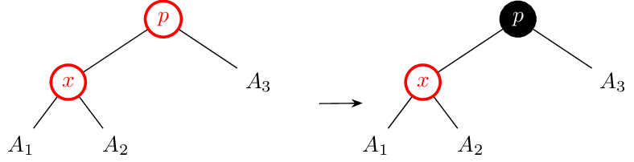

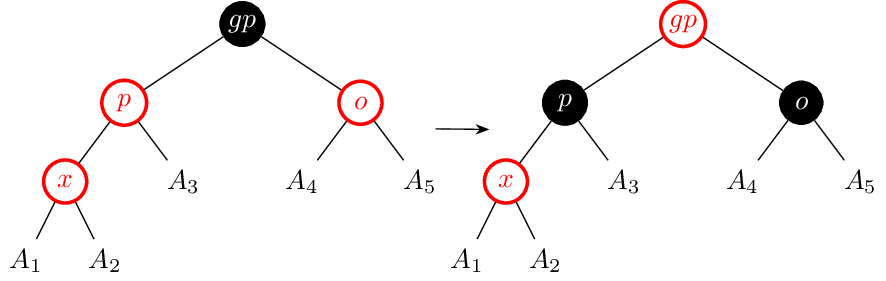

- Si $p$ est le fils gauche de son père $gp$ :
  - lorsque $x$ est le fils gauche de $p$, on effectue une rotation droite entre $p$ et $gp$, et on colorie $p$ en noir et $gp$ en rouge.</br>

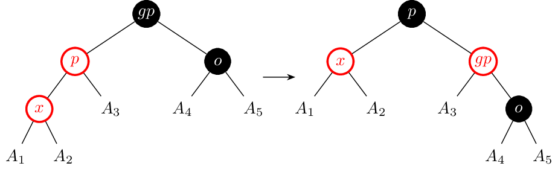

  - lorsque $x$ est le fils droit de $p$, on effectue d'abord une rotation gauche entre $x$ et $p$, ce qui ramène au cas précédent.

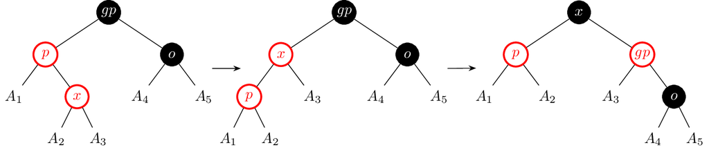

- Si $p$ est le fils droit de son père : on procède de manière symétrique au cas précédent.

Écrire une fonction `insere_RN : 'a -> 'a arbreRN -> 'a arbre RN` qui prend en argument un élément $x$ de type `'a` et un arbre rouge et noir $a$ et qui renvoie l'arbre obtenu en insérant $x$ dans l'arbre $a$ en conservant la structure d'arbre rouge et noir.

```python
let traite_conflit a =
  match a with
  | Noeud(Noir, gp,
            Noeud(Rouge, p, Noeud (Rouge, x, a1,a2), a3),
          Noeud(Rouge, o, a4, a5)) ->
    Noeud(Rouge, gp,
          Noeud(Noir, p, Noeud (Rouge, x, a1,a2), a3),
          Noeud(Noir, o, a4, a5)),
    false
  | Noeud(Noir, gp,
            Noeud(Rouge, p, a1, Noeud (Rouge, x, a2, a3)),
          Noeud(Rouge, o, a4, a5)) ->
    Noeud(Rouge, gp,
          Noeud(Noir, p, a1, Noeud (Rouge, x, a2, a3)),
          Noeud(Noir, o, a4, a5)),
    false
  | Noeud(Noir, gp,
          Noeud(Rouge, p, Noeud (Rouge, x, a1,a2), a3),
          a4) ->
    Noeud(Noir, p,
          Noeud(Rouge, x, a1, a2),
          Noeud(Rouge, gp, a3, a4)
         ),
    true
  | Noeud(Noir, gp,
          Noeud(Rouge, p, a1, Noeud (Rouge, x, a2, a3)),
          a4) ->
    Noeud(Noir, x,
          Noeud(Rouge, p, a1, a2),
          Noeud(Rouge, gp, a3, a4)
         ),
    true
  | Noeud(Noir, gp,
          a1,
          Noeud(Rouge, p, Noeud (Rouge, x, a2, a3), a4)) ->
    Noeud(Noir, x,
          Noeud(Rouge, gp, a1,a2),
          Noeud(Rouge, p, a3, a4)
         ),
    true
  | Noeud(Noir, gp,
          a1,
          Noeud(Rouge, p, a2, Noeud (Rouge, x, a3, a4))
         ) ->
    Noeud(Noir, p,
          Noeud(Rouge, gp, a1, a2),
          Noeud(Rouge, x, a3, a4)
         ),
    true
  | _ -> a, false
;;

let insere_RN x a =
  let rec insere_RN_avec_conflit x a =
    (* Renvoie un ARN avec la nouvelle étiquette et un booléen indiquant si le conflit potentiel a été réglé *)
    match a with
    | Vide -> Noeud (Rouge, x, Vide, Vide), false
    | Noeud (c, e, fg, fd) ->
      let new_a, conflit_regle =
        if x < e
        then
          let new_fg, conflit_regle = insere_RN_avec_conflit x fg in
          Noeud (c, e, new_fg, fd), conflit_regle
        else
          let new_fd, conflit_regle = insere_RN_avec_conflit x fd in
          Noeud (c, e, fg, new_fd), conflit_regle
      in
      if not conflit_regle
      then traite_conflit new_a
      else new_a, true
  in
  match insere_RN_avec_conflit x a with
  | Noeud (Rouge, e, fg, fd), _ -> Noeud (Noir, e, fg, fd)
  | arbre, _ -> arbre
;;
```

```
val traite_conflit : 'a arbreRN -> 'a arbreRN * bool = <fun>
```

```
val insere_RN : 'a -> 'a arbreRN -> 'a arbreRN = <fun>
```